# Лабораторная работа №3

Управляющие структуры

Ведьмина Александра Сергеевна

1132236003@rudn.ru

Российский университет дружбы народов

2026-10-02

## Содержание

- цель и задачи;
- проект `DrWatson`;
- циклы и условия;
- функции и `broadcast`;
- матричные задания;
- функция `outer`;
- система и двойные суммы;
- notebook, Quarto и тесты.

# Информация

## Докладчик

- Ведьмина Александра Сергеевна
- студентка
- кафедра теории вероятностей и кибербезопасности
- Российский университет дружбы народов
- 1132236003@rudn.ru

# Вводная часть

## Цель и задачи

**Цель:** освоить управляющие структуры Julia и применить их к задачам линейной алгебры и работе с матрицами.

Задачи:

- повторить `while`, `for`, `if` и тернарный оператор;
- изучить формы функций, `map` и `broadcast`;
- выполнить 11 самостоятельных заданий;
- сформировать обобщаемые матричные алгоритмы;
- получить notebook и Quarto-документ;
- проверить решения автоматическими тестами.

## Инструменты

- Julia `1.12.5`;
- `DrWatson` — структура проекта;
- `Colors` — сторонний пакет из примеров;
- `LinearAlgebra` и `Random`;
- `Literate` — единый источник документов;
- `IJulia` и Jupyter Lab;
- Quarto — HTML, PDF и презентация;
- `Test` — автоматическая проверка.

# Проект `DrWatson`

## Создание нового проекта

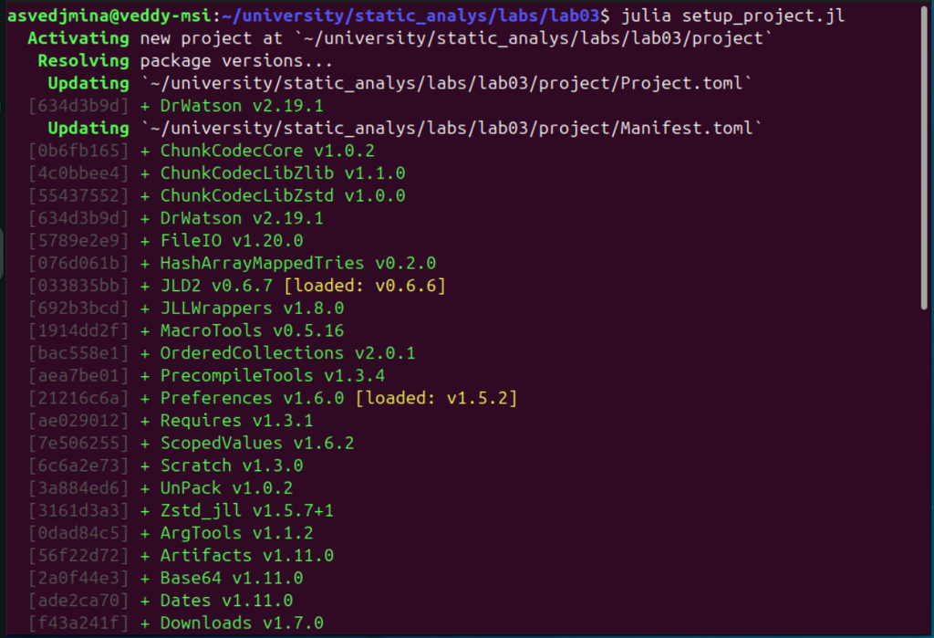

`initialize_project` создал:

- `Project.toml` и `Manifest.toml`;
- `src/` и `scripts/`;
- `data/`, `plots/`, `notebooks/`;
- `test/`;
- окружение с `DrWatson`.

## Установка зависимостей

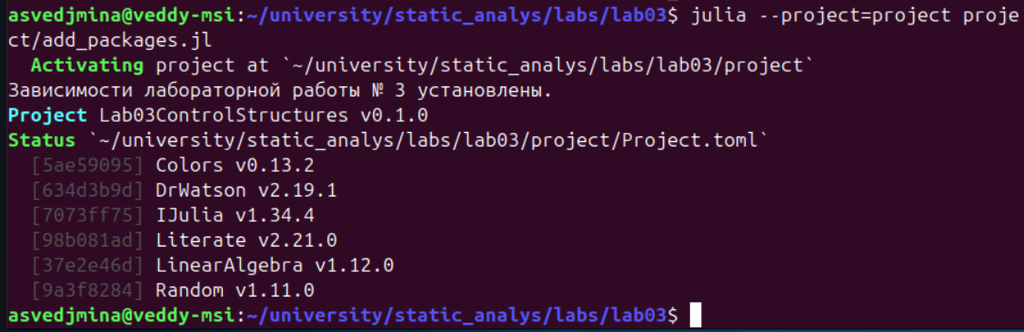

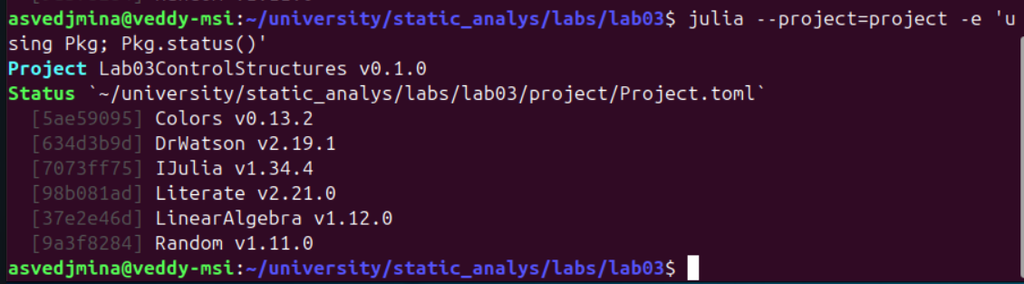

- зависимости установлены и скомпилированы;
- версии зафиксированы в `Manifest.toml`.

## Активация окружения

[figure not shown]

Julia запущена с `--project`.

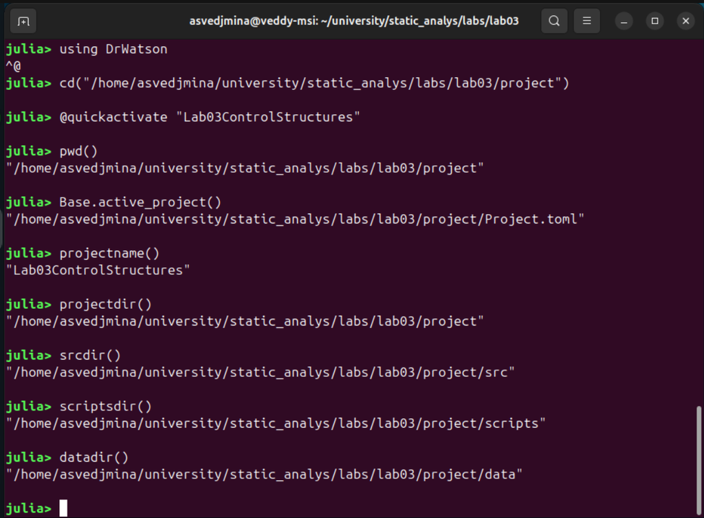

Проверены `projectdir`, `srcdir`, `scriptsdir` и `datadir`.

# Управляющие структуры

## Циклы `while` и `for`

```julia
n = 0
while n < 10
    global n += 1
    println(n)
end

for friend in myfriends
    println("Hi $friend!")
end

A = [i + j for i in 1:5, j in 1:5]
```

- `while` выполняется, пока условие истинно;
- `for` перебирает диапазон или коллекцию;
- comprehension компактно создаёт матрицу.

## Условия и функции

```julia
function fizzbuzz(number)
    if number % 15 == 0
        return "FizzBuzz"
    elseif number % 3 == 0
        return "Fizz"
    elseif number % 5 == 0
        return "Buzz"
    else
        return number
    end
end

f(x) = x^2
f3 = x -> x^2
```

## `map` и `broadcast`

Для матрицы $A$:

```julia
map(f, [1, 2, 3])
broadcast(f, [1, 2, 3])
f.(A)

@. A + 2 * f(A) / A
```

- `f(A)` вычисляет матричный квадрат $A^2$;
- `f.(A)` возводит в квадрат каждый элемент;
- точечный синтаксис объединяет поэлементные операции.

## Сторонний пакет `Colors`

```julia
palette = distinguishable_colors(100)
rng = MersenneTwister(2026)
color_matrix = rand(
    rng, palette, 3, 3,
)
display(color_matrix)
```

- создана палитра из `100` оттенков;
- seed обеспечивает воспроизводимость.

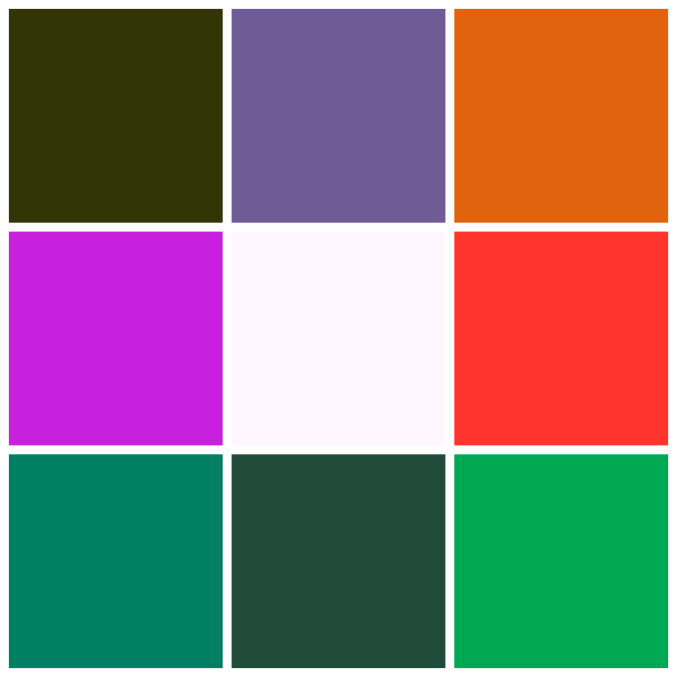

Матрица случайных цветов $3\times3$.

# Самостоятельная работа

## Задание 1: цикл `while`

```julia
number = 1
while number <= 100
    square = number^2
    squares[number] = square
    push!(squares_arr, square)
    number += 1
end
```

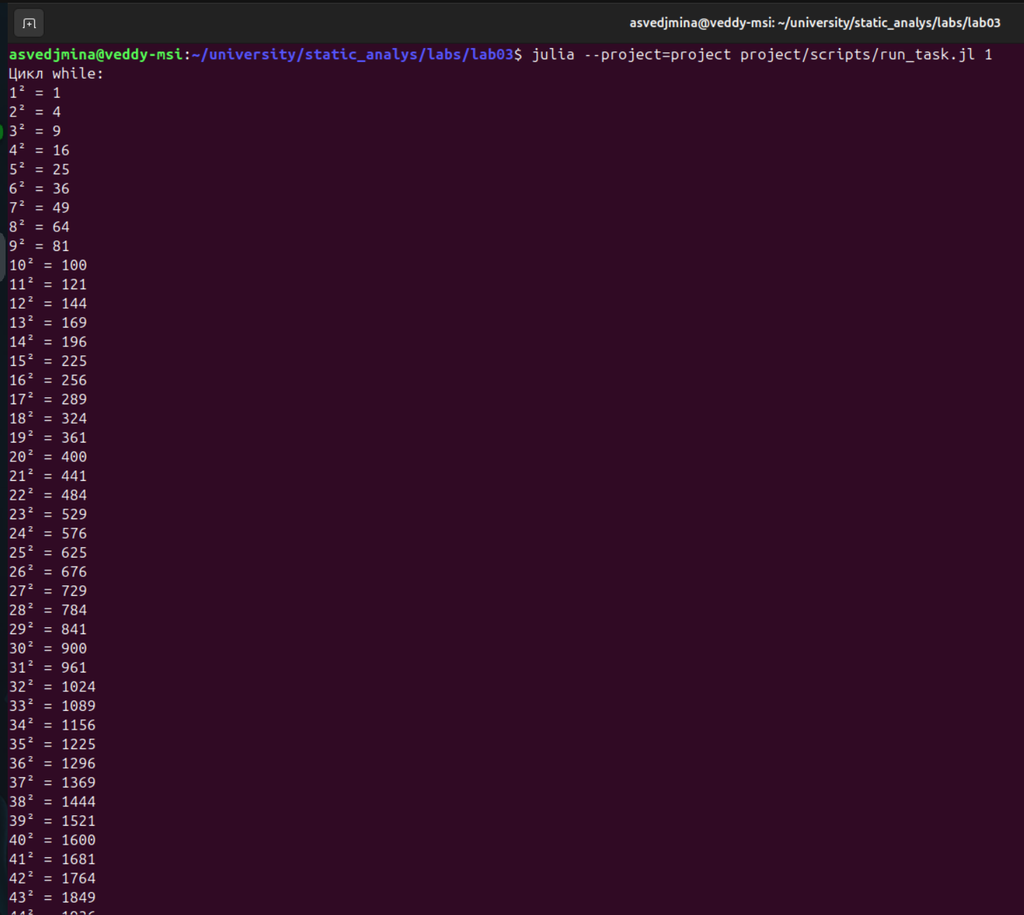

## Задание 1: полный результат

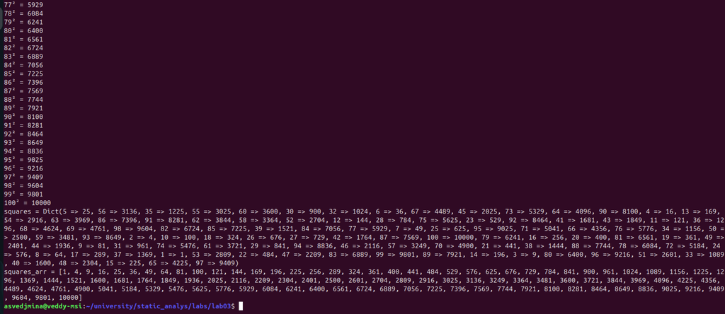

- выведены все числа и квадраты;
- `squares[10] == 100`;
- `squares_arr[end] == 10000`;
- реализации `while` и `for` совпали.

## Задания 2 и 3

```julia
function even_or_odd(number)
    if iseven(number)
        return number
    else
        return "нечётное"
    end
end

even_or_odd_ternary(number) =
    iseven(number) ? number : "нечётное"

add_one(value) = value + one(value)
```

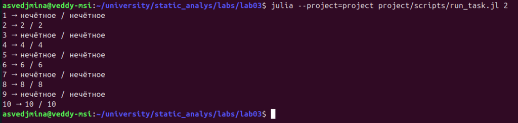

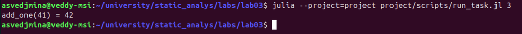

## Задание 4: возрастающая матрица

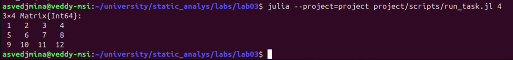

```julia
predecessors = [
    (row - 1) * columns + column - 1
    for row in 1:rows, column in 1:columns
]
A = map(add_one, predecessors)
```

## Задание 5: третья степень

```julia
A = [1 1 3;
     5 2 6;
    -2 -1 -3]

A_cubed = A^3
A_modified = copy(A)
A_modified[:, 3] .=
    A[:, 2] .+ A[:, 3]
```

Результат: $A^3=0$.

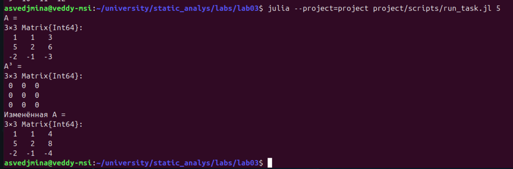

## Задание 6: матрицы $B$ и $C$

```julia
B = repeat([10 -10 10], 15, 1)
C = transpose(B) * B
```

$$C=\begin{pmatrix}
1500&-1500&1500\\
-1500&1500&-1500\\
1500&-1500&1500
\end{pmatrix}.$$

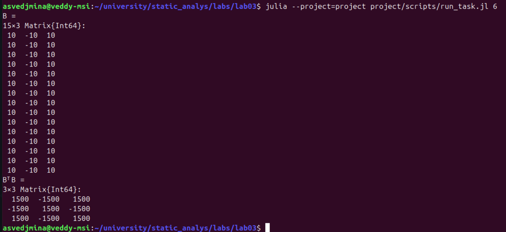

## Задание 7: структурные матрицы

```julia
for i in 1:n, j in 1:n
    Z1[i, j] = abs(i - j) == 1
    Z2[i, j] =
        abs(i - j) in (0, 2)
    reflected = n - j + 1
    Z3[i, j] =
        abs(i - reflected) in (0, 2)
    Z4[i, j] = iseven(i + j)
end
```

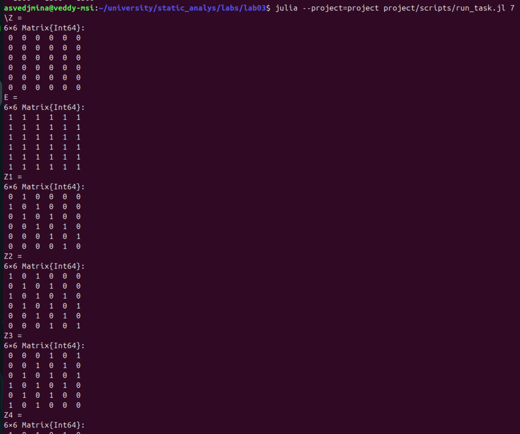

## Задание 8: функция `outer`

```julia
function outer(x, y, op)
    [op(a, b)
     for a in x, b in y]
end

function outer(A, B, op)
    [sum(op(A[i, k], B[k, j])
         for k in axes(A, 2))
     for i in axes(A, 1),
         j in axes(B, 2)]
end
```

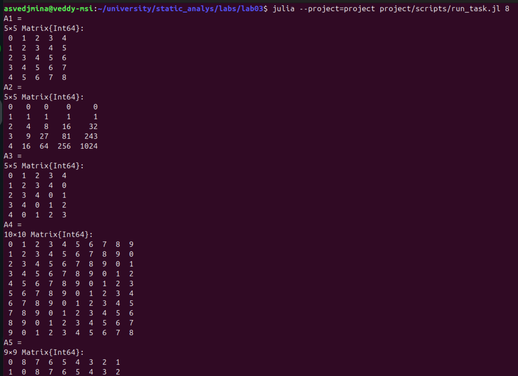

## Матрицы функции `outer`

| Матрица | Размер | Элемент |
| --- | --- | --- |
| $A_1$ | $5\times5$ | $i+j$ |
| $A_2$ | $5\times5$ | $i^{j+1}$ |
| $A_3$ | $5\times5$ | $(i+j)\bmod5$ |
| $A_4$ | $10\times10$ | $(i+j)\bmod10$ |
| $A_5$ | $9\times9$ | $(i-j)\bmod9$ |

Проверка:

```julia
outer(A, B, *) == A * B  # true
```

## Задание 9: система уравнений

```julia
n = length(y)
A = [abs(i - j) + 1
     for i in 1:n, j in 1:n]
x = A \ y
```

$$x=(-2,3,5,2,-4)^T.$$

Проверка `A*x ≈ y` истинна.

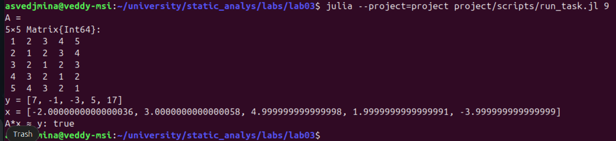

## Задание 10: случайная матрица

```julia
rng = MersenneTwister(2026)
M = rand(rng, 1:10, 6, 10)

greater_counts = vec(
    sum(M .> 4; dims=2),
)
matching_rows = findall(
    vec(sum(M .== 7; dims=2)) .== 2,
)
```

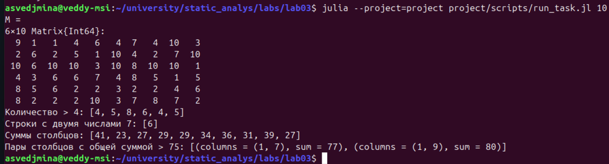

## Результаты задания 10

| Показатель | Результат |
| --- | --- |
| Элементов $>4$ по строкам | `[4, 5, 8, 6, 4, 5]` |
| Две семёрки | строка `6` |
| Суммы столбцов | `41, 23, 27, 29, 29, 34, 36, 31, 39, 27` |
| Сумма пары $>75$ | `(1,7): 77`, `(1,9): 80` |

Фиксированное начальное состояние генератора обеспечивает воспроизводимость.

## Задание 11: двойные суммы

```julia
S1 = sum(
    big(i)^4 // big(3 + j)
    for i in 1:20 for j in 1:5
)

S2 = sum(
    big(i)^4 // big(3 + i * j)
    for i in 1:20 for j in 1:5
)
```

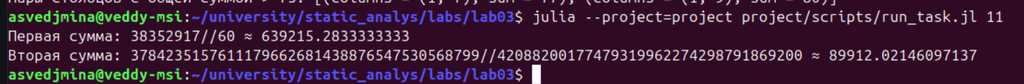

$$S_1\approx639215{,}2833,\qquad
S_2\approx89912{,}02146.$$

# Воспроизводимые материалы

## Генерация документов

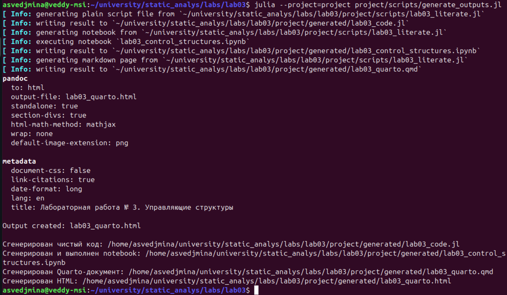

Из одного literate-источника получены:

- `lab03_code.jl`;
- выполненный notebook;
- `lab03_quarto.qmd`;
- `lab03_quarto.html`.

## Quarto

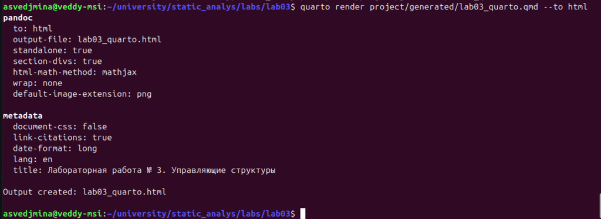

Рендеринг завершён без ошибок.

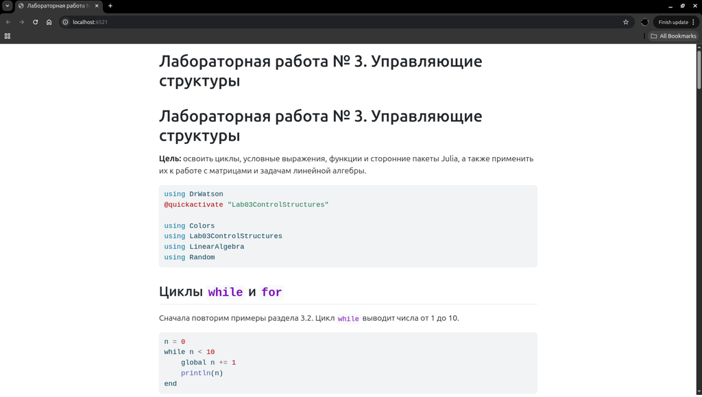

HTML проверен в браузере.

[figure not shown]

## Выполненный notebook: начало

[figure not shown]

Начальные ячейки содержат цель работы и примеры циклов `while` и `for`.

## Выполненный notebook: матрицы

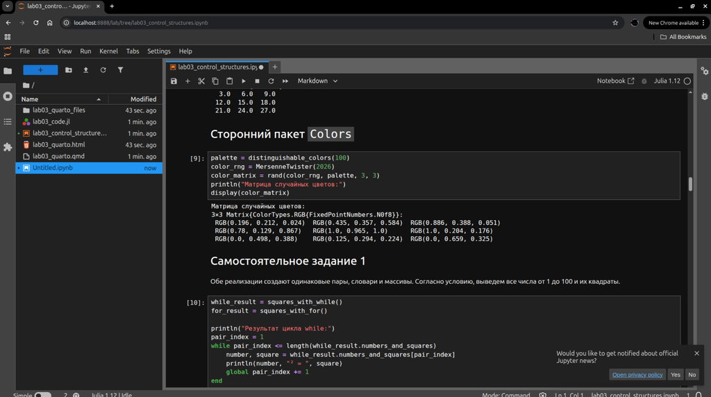

## Выполненный notebook: итог

[figure not shown]

В заключительной части находятся двойные суммы и общий вывод.

## Автоматические тесты

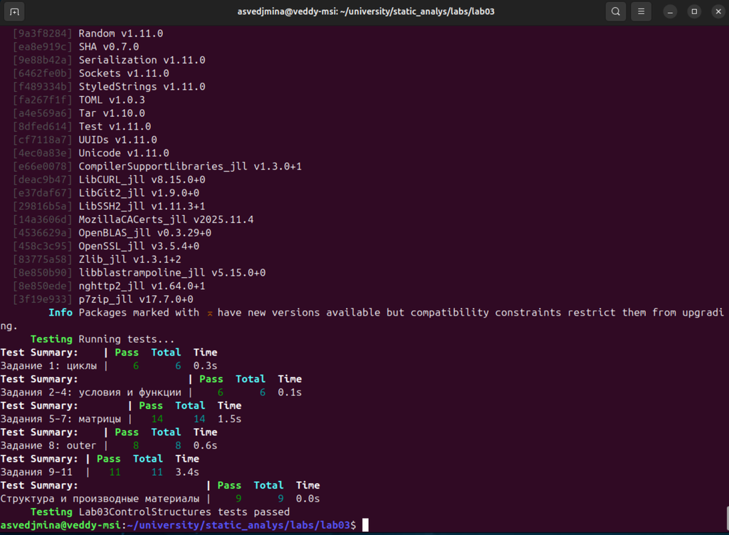

Проверены:

- циклы, условия и функции;
- все матричные задания;
- `outer` и система уравнений;
- случайная матрица и суммы;
- производные материалы.

Все `54` теста пройдены.

# Результаты

## Сводная таблица

| Задание | Основной результат |
| --- | --- |
| 1 | $100^2=10000$ |
| 5 | $A^3=0$ |
| 6 | $C_{11}=C_{22}=C_{33}=1500$ |
| 8 | построено пять семейств матриц |
| 9 | $x=(-2,3,5,2,-4)^T$ |
| 10 | пары `(1,7)` и `(1,9)` |
| 11 | $S_1=38352917/60$ |

## Воспроизводимость

- решения вынесены в модуль `Lab03ControlStructures`;
- размерности структурных матриц задаются параметрами;
- случайная матрица фиксируется `seed=2026`;
- большие рациональные суммы вычисляются без переполнения;
- код, notebook и Quarto создаются из одного источника;
- окружение зафиксировано `Project.toml` и `Manifest.toml`;
- корректность подтверждена тестами.

# Выводы

## Итоги работы

- освоены циклы и условные выражения Julia;
- изучены функции, `map` и `broadcast`;
- выполнены все 11 самостоятельных заданий;
- реализованы обобщаемые матричные алгоритмы;
- решена структурная система линейных уравнений;
- сформированы notebook и Quarto-документ;
- все `54` теста успешно пройдены.

Цель лабораторной работы достигнута.